# Find in Packages

6. Juni 2019

## Aufgabenstellung

> Erstellung eines Pakets zum Auflisten aller (.packages(TRUE)) in der eigenen R-Library vorhandener Daten, die bestimmte (Teil-)Wörter enthalten.

## Aufgabenstellung

Also hä?

## Aufgabenstellung

- Erstellung eines Pakets
- zum Auflisten aller (.packages(TRUE))
- in der eigenen R-Library vorhandener Daten,
- die bestimmte (Teil-)Wörter enthalten.

## Die Reise beginnt

Zieht bitte feste Schuhe an. R ist voller Stolpersteine

## .packages(TRUE)

Was ist *.packages(TRUE)*?

## .packages(TRUE)

Was ist *.packages(TRUE)*?

```r
.packages(TRUE)
```

```
##   [1] "ada"            "askpass"        "assertthat"     "backports"
##   [5] "base"           "base64enc"      "BH"             "bit"
##   [9] "bit64"          "blob"           "boot"           "brew"
##  [13] "callr"          "class"          "cli"            "clipr"
##  [17] "clisymbols"     "cluster"        "codetools"      "commonmark"
##  [21] "compiler"       "crayon"         "curl"           "data.table"
##  [25] "datasets"       "DBI"            "desc"           "devtools"
##  [29] "digest"         "e1071"          "evaluate"       "evd"
##  [33] "fansi"          "fastmatch"      "ff"             "ffbase"
##  [37] "findInPackages" "foreign"        "fs"             "gh"
##  [41] "git2r"          "glue"           "graphics"       "grDevices"
##  [45] "grid"           "highr"          "htmltools"      "httr"
##  [49] "ini"            "ipred"          "jsonlite"       "KernSmooth"
##  [53] "knitr"          "lattice"        "lava"           "magrittr"
##  [57] "markdown"       "MASS"           "Matrix"         "memoise"
##  [61] "methods"        "mgcv"           "mime"           "nlme"
##  [65] "nnet"           "numDeriv"       "openssl"        "parallel"
##  [69] "pillar"         "pkgbuild"       "pkgconfig"      "pkgload"
##  [73] "plogr"          "prettyunits"    "processx"       "prodlim"
##  [77] "ps"             "purrr"          "R6"             "rcmdcheck"
##  [81] "Rcpp"           "RecordLinkage"  "remotes"        "rlang"
##  [85] "rmarkdown"      "roxygen2"       "rpart"          "rprojroot"
##  [89] "RSQLite"        "rstudioapi"     "sessioninfo"    "spatial"
##  [93] "splines"        "SQUAREM"        "stats"          "stats4"
##  [97] "stringi"        "stringr"        "survival"       "sys"
## [101] "tcltk"          "tibble"         "tinytex"        "tools"
## [105] "translations"   "usethis"        "utf8"           "utils"
## [109] "whisker"        "withr"          "xfun"           "xml2"
## [113] "xopen"          "xtable"         "yaml"
```

## .packages(TRUE)

Was ist *.packages(TRUE)*?

Listet alle installierten Packages auf

## finden

- Wie *finde* ich etwas?
- mit *grep*

## finden

- Wie *finde* ich etwas?
- mit *grep*

```r
haystack = c("Peter", "Manuel", "Hans")
grep("Peter", haystack)
```

```
## [1] 1
```

```r
grep("Man", haystack)
```

```
## [1] 2
```

```r
grep("Gregor", haystack)
```

```
## integer(0)
```

## finden mit grep

- Grep kann Teilwörter
- Regex
- case senstitive

## Aufgabenstellung

- Erstellung eines Pakets -> Später
- zum Auflisten aller (.packages(TRUE)) -> ok
- in der eigenen R-Library vorhandener Daten, -> später
- die bestimmte (Teil-)Wörter enthalten. -> ok

## Darstellung Resultat

schön wäre:

| Paketname | Im Namen enthalten | weiteres |
| --- | --- | --- |
| Packet A | TRUE | TRUE |
| Packet B | TRUE | FALSE |
| Packet C | FALSE | TRUE |
| … | … | … |

## Erste Spalte mit den Packetnamen

```r
# get and transform all installed packages
PACKAGES <- transform(.packages(TRUE))
# create the return matrix
collectedData <- data.frame(PACKAGES)
# give the column a name
colnames(collectedData) <- "Package"
## show head
head(collectedData)
```

```
##      Package
## 1        ada
## 2    askpass
## 3 assertthat
## 4  backports
## 5       base
## 6  base64enc
```

## Weitere Spalte hinzufügen

```r
# add new Column 'MyNewColumn' with all values FALSE
collectedData <- cbind(collectedData, "MyNewColumn" = FALSE)
## show head
head(collectedData)
```

```
##      Package MyNewColumn
## 1        ada       FALSE
## 2    askpass       FALSE
## 3 assertthat       FALSE
## 4  backports       FALSE
## 5       base       FALSE
## 6  base64enc       FALSE
```

## Suchfunktionen

Gut, jetzt braucht es *nur noch* Funktionen die Suchen und dabei eine Spalte zurückgeben.

Finden mit *grep* kann ich ja schon

## Die Suchfunktion

Funktion *find*

```r
find <- function (needle, haystack){
  return(length(grep(pattern = needle, x = haystack)) > 0)
}
```

Fancy Erweiterung für *grep*. Gibt *TRUE* zurück, falls mindestens ein Treffer erzielt wurde

Diese werden jetzt mittels Funktionen Suchbegriffe gefüttert und die Antwort wird gespeichert

## Suche im Paketnamen

Die einfachste Funktion ist die Suche im Packetnamen

```r
findInPackageName <- function(needle, packages){
  return(apply(packages, 1, function(packagename) find(needle, packagename)))
}
```

## Suche im Paketnamen

Die einfachste Funktion ist die Suche im Packetnamen

```r
findInPackageName <- function(needle, packages){
  return(apply(packages, 1, function(packagename) find(needle, packagename)))
}
```

Diese Funktion wird aufgerufen und die Resultate direkt an unsere Resultattablle gehängt

```r
collectedData <- cbind(collectedData, "Packagename" = findInPackageName(needle, PACKAGES))
```

## Suche im Paketnamen

```r
needle <- "as"
collectedData <- cbind(collectedData, "Packagename" = findInPackageName(needle, PACKAGES))
## show head
head(collectedData)
```

```
##      Package Packagename
## 1        ada       FALSE
## 2    askpass        TRUE
## 3 assertthat        TRUE
## 4  backports       FALSE
## 5       base        TRUE
## 6  base64enc        TRUE
```

## Suche im Paketbeschreibung

```r
needle <- "as"

findInPackageDescription <- function(needle, packages){
  return(apply(packages, 1, function(packagename){
    find(needle, packageDescription(packagename))
  }))
}

collectedData<-cbind(collectedData,"Description"=findInPackageDescription(needle, PACKAGES))

## show head
head(collectedData)
```

```
##      Package Packagename Description
## 1        ada       FALSE        TRUE
## 2    askpass        TRUE        TRUE
## 3 assertthat        TRUE        TRUE
## 4  backports       FALSE        TRUE
## 5       base        TRUE        TRUE
## 6  base64enc        TRUE        TRUE
```

## Suche in der Pakethilfe

```r
p <- "ada"
help(package = p, help_type="text")
```

Kann R so nicht bearbeiten. Deshalb

## Suche in der Pakethilfe

```r
p <- "ada"
help(package = p, help_type="text")
```

Kann R so nicht bearbeiten. Desshalb

```r
p <- "ada"
help(package = eval(p), help_type="text")
```

## Suche in der Pakethilfe

```r
needle <- "as"

findInPackageHelp <- function(needle, packages){
  return(apply(packages, 1, function(packagename){
    find(needle, help(package = eval(packagename), help_type="text"))
  }))
}
collectedData <- cbind(collectedData, "Help" = findInPackageHelp(needle, PACKAGES))

## show head
head(collectedData)
```

```
##      Package Packagename Description Help
## 1        ada       FALSE        TRUE TRUE
## 2    askpass        TRUE        TRUE TRUE
## 3 assertthat        TRUE        TRUE TRUE
## 4  backports       FALSE        TRUE TRUE
## 5       base        TRUE        TRUE TRUE
## 6  base64enc        TRUE        TRUE TRUE
```

## Suche in den Daten

- Ein Paket hat 0..* Daten
- Die Pakete *base* und *stats* haben keine Daten geben aber dafür Warnungen aus wenn man nachfragt
- Statt einem *apply* über die Werte, gibt es jetzt ein *foreach* über alle Pakete und da drin ein *lapply/apply*, welches sich noch in einem if-elseif-else befindet

## Suche in den Daten

- Ein Paket hat 0..* Daten
- Die Pakete *base* und *stats* haben keine Daten geben aber dafür Warnungen aus wenn man nachfragt
- Statt einem *apply* über die Werte, gibt es jetzt ein *foreach* über alle Pakete und da drin ein *lapply/apply*, welches sich noch in einem if-elseif-else befindet

[figure not shown]

## Suche in den Daten

```r
findInData <- function(needle, packages){
  # create an empty list for the results
  returnList <- c()

  # foreach packagename
  for (package in packages[[1]]){

    # Ignore Package 'base' and 'stats' they have no data and throw a warning
    if (package == 'base' || package == 'stats') {
      returnList <- c(returnList, FALSE)
    } else {
      # get data information for certain package
      packageData <- data(package = eval(package))
      # only the results are important
      packageData <- packageData$results

      ## [...]

    }
  }

  return(returnList)

}
```

## Suche in den Daten

```r
if (length(packageData) == 0) {
  # NO DATA HERE
  returnList <- c(returnList, FALSE)
} else if (length(packageData) == 4){
  # exactly one package

  # find for the needle in the columns item and title
  res <- lapply(packageData[,3:4], function(x) find(needle, x))
  # if one of them has the word in it return true
  returnList <- c(returnList, (res$Item || res$Title))
} else {
  # more than one
  returnList <- c(returnList, sum(apply(packageData[,3:4], 2, function(x) find(needle, x))) > 0)
}
```

## Suche in den Daten

```r
needle <- "as"

collectedData <- cbind(collectedData, "Data" = findInData(needle, PACKAGES))

## show head
head(collectedData)
```

```
##      Package Packagename Description Help  Data
## 1        ada       FALSE        TRUE TRUE FALSE
## 2    askpass        TRUE        TRUE TRUE FALSE
## 3 assertthat        TRUE        TRUE TRUE FALSE
## 4  backports       FALSE        TRUE TRUE FALSE
## 5       base        TRUE        TRUE TRUE FALSE
## 6  base64enc        TRUE        TRUE TRUE FALSE
```

## Daraus wird eine Funktion

```r
findInPackages <- function(needle){
  PACKAGES <- transform(.packages(TRUE))
  collectedData <- data.frame(PACKAGES)
  colnames(collectedData) <- "Package"

  collectedData<-cbind(collectedData,"Packagename"=findInPackageName(needle,PACKAGES))
  collectedData<-cbind(collectedData,"Description"=findInPackageDescription(needle,PACKAGES))
  collectedData<-cbind(collectedData,"Help"=findInPackageHelp(needle,PACKAGES))
  collectedData<-cbind(collectedData,"Data"=findInData(needle,PACKAGES))

  # reset row numbering
  rownames(collectedData) <- seq(length=nrow(collectedData))

  # Return everything
  collectedData
}
```

## Zeige nur relevante Resultate

```r
  head(findInPackages("ase"))
```

```
##      Package Packagename Description  Help  Data
## 1        ada       FALSE       FALSE FALSE FALSE
## 2    askpass       FALSE        TRUE  TRUE FALSE
## 3 assertthat       FALSE        TRUE  TRUE FALSE
## 4  backports       FALSE        TRUE  TRUE FALSE
## 5       base        TRUE        TRUE  TRUE FALSE
## 6  base64enc        TRUE        TRUE  TRUE FALSE
```

## Zeige nur relevante Resultate

```r
    toKeep <- apply(collectedData[,2:length(collectedData)], 1,  sum) > 0
    collectedData <- collectedData[toKeep,]
```

```r
  head(findInPackages("ase"))
```

```
##      Package Packagename Description Help  Data
## 1    askpass       FALSE        TRUE TRUE FALSE
## 2 assertthat       FALSE        TRUE TRUE FALSE
## 3  backports       FALSE        TRUE TRUE FALSE
## 4       base        TRUE        TRUE TRUE FALSE
## 5  base64enc        TRUE        TRUE TRUE FALSE
## 6         BH       FALSE        TRUE TRUE FALSE
```

## Dem User Macht geben

```r
findInPackages <- function(
  needle,
  ignore.case=TRUE,
  ..., # additional Parameters for grep
  lookInPackagename=TRUE,
  lookInDescription=TRUE,
  lookInHelp=TRUE,
  lookInData=TRUE,
  showOnlyContaining=TRUE
){
```

## Elipsis witergeben

```r
find <- function (needle, haystack, ignorecase, ...){
  return(length(grep(pattern = needle, x = haystack, ignore.case = ignorecase, ...)) > 0)
}

findInPackageName <- function(needle, packages, ignore.case, ...){
  return(apply(packages, 1, function(packagename) find(needle, packagename, ignore.case, ...)))
}
```

## Aufgabenstellung

- Erstellung eines Pakets -> jetzt
- zum Auflisten aller (.packages(TRUE)) -> ok
- in der eigenen R-Library vorhandener Daten, -> ok
- die bestimmte (Teil-)Wörter enthalten. -> ok

## package

Paketbeschreib mit *Roxygen2*

```r
#' Find in Packages
#'
#' Function that allows you to search in all installed packages for a specific string
#' @param needle character string containing a string or regular expression specifying want you to search for
#' @param ignore.case logical. if \code{FALSE} the pattern matching is \emph{case sensitive}
#' @param ... additional parameters for \code{\link[base:grep]{grep}}
#' [...]
#' @param showOnlyContaining logical. if \code{TRUE} only packages that have one match will be displayed
#' @return
#' \code{findInPackages("mtcars")} returns a table with all Packages that match for the word \emph{mtcars} in either the packagename, description, help or data
#' @export findInPackagesc
#' @examples
#' findInPackages("mtcars")
#'   Package  Packagename Description Help  Data
#' 1 datasets FALSE       FALSE       TRUE  TRUE
#'
"findInPackages"
```

## package

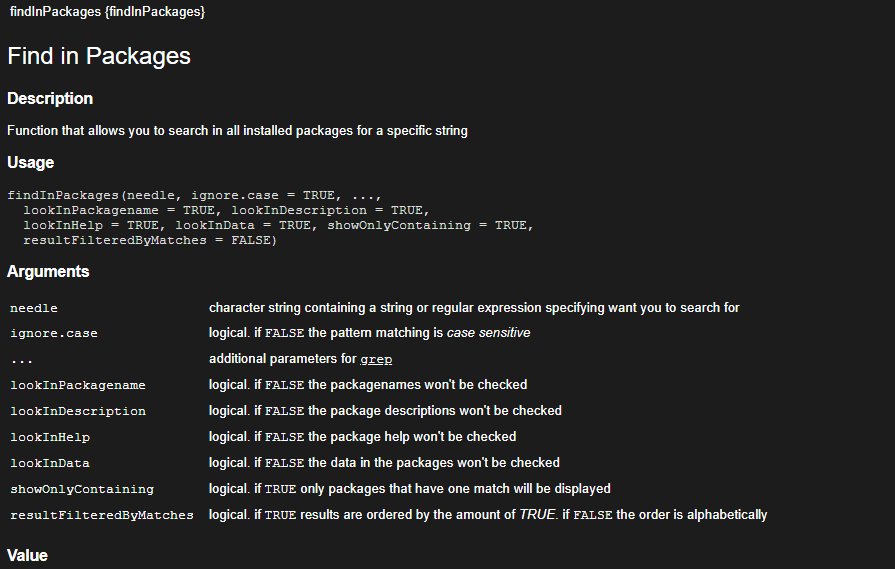

```r
library(findInPackages)
?findInPackages
```

## Wo sind die Survivor?

```r
findInPackages("survival")
```

```
##    Package Packagename Description Help  Data
## 1     boot       FALSE        TRUE TRUE  TRUE
## 2    ipred       FALSE        TRUE TRUE FALSE
## 3     lava       FALSE        TRUE TRUE FALSE
## 4     MASS       FALSE        TRUE TRUE FALSE
## 5     mgcv       FALSE        TRUE TRUE FALSE
## 6  prodlim       FALSE        TRUE TRUE FALSE
## 7    rpart       FALSE        TRUE TRUE FALSE
## 8 survival        TRUE        TRUE TRUE  TRUE
## 9   xtable       FALSE        TRUE TRUE FALSE
```

## Zukunft

- Suche innerhalb der *Dimnames*
  - Schwierig, da die Daten nicht immer in der gleichen Struktur vorliegen
- Suche innerhalb der Zellen